# Discussion on Distributions

- We need to recall some information from our previous readings:
  - **Random Variables** are mappings (or assignments) from real random events to numbers
  - RVs give us a way to discuss the frequency and variation of events
    - We can compute **centrality** and **dispersion** measures for random variables
      - Mean, median, mode
      - Variance, standard deviation

## Probability

- The **probability** of a random event happening is the chance, or likelihood, of that event
- The probability of a particular random event, $A$, are defined as the following ratio:

$$ \frac{\text{Number of Ways to Obtain Event } A}{\text{Total Number of Possible Events}} $$

For example, if we want to calculate the probability of rolling a 4 on a dice, we count the number of ways to obtain a 4 (there is only one way), and we divide by the total number of possible events (six different events, because it's a six sided dice). Thus the probability of rolling a 4 is $1/6$.

### Quick Excercise

Let us assume we will roll two regular dice, each with six sides. After rolling the two dice, we **add** their numbers and the result will be our total. What is the probability of getting a total of **4**?

- Question 1: How many total possible events are there?
  - 6 possibilities for the first dice
  - 6 possibilities for the second dice
  - So 6*6 = 36 total possible dice rolls
- Question 2: How many ways could we get a total of 4?
  - 1 + 3 = 4
  - 2 + 2 = 4
  - 3 + 1 = 4
  - Three ways!
- So the probability of getting a total of 4 is $$ \frac{3}{36} = \frac{1}{12} .$$

We could easily do this for the other possible outcomes of rolling a dice. For example:

- What is the probability of getting a total of 7?
  - There are six ways to get seven!
    - 1 + 6
    - 2 + 5
    - 3 + 4
    - 4 + 3
    - 5 + 2
    - 6 + 1
  - So the probability of getting a total of 7 is $$ \frac{6}{36} = \frac{1}{6} .$$

## Probability Distribution Function

- A mathematical function that gives the probability of all events for a particular random variable
- Often written as $P(x)$, where $x$ is the random variable

Example:

We usually first need to clearly define our random variable. Let's do that for our example from before:

$$ x = \begin{cases} 2 & \text{if }(1+1) \\\\ 3 & \text{if }(1+2,2+1) \\\\ 4 & \text{if }(1+3,2+2,3+1) \\\\ 5 & \cdots \\\\ 6 & \cdots \\\\ 7 & \cdots \\\\ 8 & \cdots \\\\ 9 & \cdots \\\\ 10 & \cdots \\\\ 11 & \text{if }(5+6,6+5) \\\\ 12 & \text{if }(6+6) \\\\ \end{cases} $$

Now that we have the random variable defined, we can write down the probability distribution function *for that random variable* as follows:

```python
x = [2,3,4,5,6,7,8,9,10,11,12]
Px = [1/36, 2/36, 3/36, 4/36, 5/36, 6/36, 5/36, 4/36, 3/36, 2/36, 1/36]
```

```python
Px
```

```
[0.027777777777777776,
 0.05555555555555555,
 0.08333333333333333,
 0.1111111111111111,
 0.1388888888888889,
 0.16666666666666666,
 0.1388888888888889,
 0.1111111111111111,
 0.08333333333333333,
 0.05555555555555555,
 0.027777777777777776]
```

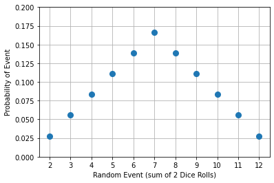

```python
import matplotlib.pyplot as plt
plt.plot(x,Px,
         marker='o',
         markersize=8,
         linestyle="none")
plt.ylim(0,0.2); plt.xticks(range(2,13))
plt.xlabel("Random Event (sum of 2 Dice Rolls)")
plt.ylabel("Probability of Event")
plt.grid()
plt.show()
```

In a sense, this picture gives us the **shape** of what a data set would look like, since we would expect outcomes with high probability to happen more frequently.

## Properties of Probability Distribution Functions

1. All probabilities MUST be between 0 and 1
   $$ 0 \leq P(x) \leq 1 $$
2. The sum of all probabilities, over all events, must equal 1
   $$ \sum P(x) = 1 $$

```python
x
```

```
[2, 3, 4, 5, 6, 7, 8, 9, 10, 11, 12]
```

```python
Px
```

```
[0.027777777777777776,
 0.05555555555555555,
 0.08333333333333333,
 0.1111111111111111,
 0.1388888888888889,
 0.16666666666666666,
 0.1388888888888889,
 0.1111111111111111,
 0.08333333333333333,
 0.05555555555555555,
 0.027777777777777776]
```

```python
sum(Px)
```

```
1.0000000000000002
```

Notice the 2 at the end? That is from the computer not being able to *perfectly* represent fractions internally. Fortunately, it is such a small error that it will almost never matter to us.

- It has the same error as trying to measure the length of a kitchen table and being off by the width of a hydrogen nucleus.

## Computing the Mean using a PDF

- We had previously learned that the mean of a data set is defined as the following:
  $$ \bar{x} = \frac{1}{n}\sum_{i=1}^n x_i $$
- We can also compute the mean using the Probability Distribution directly: $$ E[X] = \sum_{x\in X} x P(x) $$
- When we have a large collection of data, these should give the same number.

```python
x_dice = [1, 2, 3, 4, 5, 6]
Px_dice = [1/6, 1/6, 1/6, 1/6, 1/6, 1/6]
```

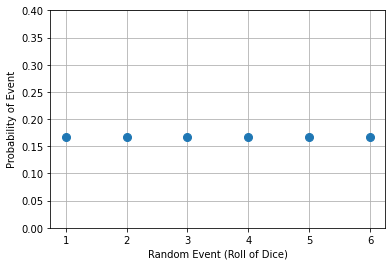

```python
plt.plot(x_dice,Px_dice,marker='o', markersize=8, linestyle="none")
plt.ylim(0,0.4); plt.xticks(range(1,7))
plt.xlabel("Random Event (Roll of Dice)")
plt.ylabel("Probability of Event")
plt.grid()
plt.show()
```

```python
sum([x_dice[i] * Px_dice[i] for i in range(6)])
```

```
3.5
```

```python
sum([x[i] * Px[i] for i in range(11)])
```

```
6.999999999999999
```

## Continuous Random Variables

- The Random Variables discussed above are all *discrete* random variables
  - There are a finite number of possible events
- Continuous random variables have infinitely many possible events
  - Example: Your height, weight, and average driving speed
  - Probabilities for *individual* and *specific* values do not make sense
    - What's the probability of being EXACTLY 6ft tall?
  - Instead, we can talk about the probability of being in *ranges* of possible values
    - What's the probability of being ABOVE 6ft tall?
- While slightly more complex, these continuous random variables are extremely useful

## Theoretical Distributions

- Instead of observing real-world data and *finding* their distributions, we can instead use mathematical reasoning to create theoretical ones
- These theoretical distributions allow us to use an idealized function to describe real world data
  - Real world distributions (especially for continuous random variables) are usually very complex and generally unknowable

## Continous Distributions

- The **Normal Distribution** is a very common, continuous distribution. It goes by several other names:
  - Gaussian Distribution
  - Bell Curve
  - Normal Curve
- While it is a model distribution, but it does a very good job describing many common phenomena
  - Why? Because it can be proven that the sum of many independent processes (each of which can be a random variable) will always *approach* a Normal distribution
- The function that defines the shape of the Normal distribution is fairly complex:

$$ N(\mu, \sigma) \sim \frac{1}{\sqrt{2\pi \sigma^2}}e^{-\frac{(x-\mu)^2}{2\sigma^2}} $$

```python
import numpy as np
x = np.arange(-5,5,step=0.01)
y = (1/(np.sqrt(2*np.pi))) * np.exp(-((x)**2/(2)))
```

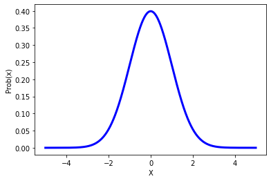

```python
plt.plot(x,y, linewidth=3, color="blue")
plt.xlabel("X")
plt.ylabel("Prob(x)")
plt.show()
```

- The average of a Normal distribution is determined by the $\mu$ parameter and the standard deviation is $\sigma$.
- This makes it easy to create and work with the Normal

## Sampling

- The above distributions, both discrete and continous, theoretical or emprical, exist independent of any actual events taking place
- Once we observe an actual event happen, we have realized an *instance* of the random variable
- A **sample** is a collection of observations of a particular random variable
  - The sample and the distribution are *not the same thing*

### Example with Dice Rolls

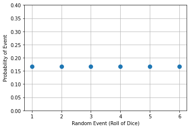

```python
plt.plot(x_dice,Px_dice,marker='o', markersize=8, linestyle="none")
plt.ylim(0,0.4); plt.xticks(range(1,7))
plt.xlabel("Random Event (Roll of Dice)")
plt.ylabel("Probability of Event")
plt.grid()
plt.show()
```

```python
x_data = np.random.randint(1,7,size=10000)
```

```python
x_data
```

```
array([2, 5, 5, ..., 4, 5, 1])
```

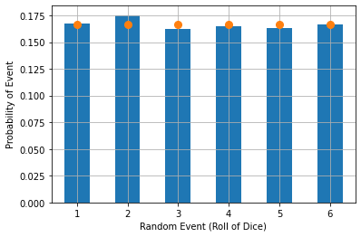

```python
plt.hist(x_data, bins=np.arange(0.75,7.75),density=True, width=0.5)
plt.plot(x_dice,Px_dice,marker='o', markersize=8, linestyle="none")
plt.xticks(range(1,7))
plt.xlim(0.5,6.5)
plt.xlabel("Random Event (Roll of Dice)")
plt.ylabel("Probability of Event")
plt.grid()
plt.show()
```

```python
np.mean(x_data)
```

```
3.4805
```

### Example with Normal Distribution

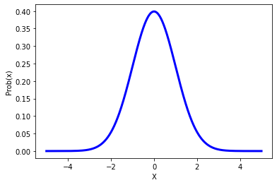

```python
plt.plot(x,y, linewidth=3, color="blue")
plt.xlabel("X")
plt.ylabel("Prob(x)")
plt.show()
```

```python
x_data = np.random.randn(1)
```

```python
x_data
```

```
array([-0.74238693])
```

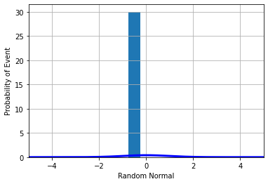

```python
plt.hist(x_data, bins=30, density=True, width=0.5)
plt.plot(x,y, linewidth=3, color="blue")
plt.xlim(-5,5)
plt.xlabel("Random Normal")
plt.ylabel("Probability of Event")
plt.grid()
plt.show()
```

```python
np.mean(x_data)
```

```
-0.7423869299584458
```

## Central Limit Theorem

- We said earlier that some processes will *approach* a Normal distribution eventually
- This can directly be shown by a simple simulation:
1. Go to each classroom of students and ask each student how many cups of coffee they drink a day
   - Each student will have some number, maybe several are zero
2. For each classroom, add up the numbers given by the students
3. Repeat this process, going from room to room.

While the distribution of the number of cups of coffee each student drinks will **not** be normally distributed (it's not even continuous!) the SUM of it will be

```python
r = 30
classroom = np.floor(np.random.exponential(scale=2,size=r))
```

```python
classroom
```

```
array([0., 4., 0., 1., 1., 1., 1., 1., 8., 1., 0., 7., 0., 2., 0., 1., 0.,
       0., 2., 1., 2., 0., 0., 8., 0., 0., 0., 0., 1., 0.])
```

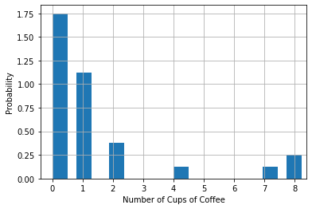

```python
plt.hist(classroom, bins=30, density=True, width=0.5)
plt.xlabel("Number of Cups of Coffee")
plt.ylabel("Probability")
plt.grid()
plt.show()
```

```python
np.sum(classroom)
```

```
42.0
```

```python
N = 10
many_rooms = [np.sum(np.floor(np.random.exponential(scale=2,size=r))) for i in range(N)]
```

```python
many_rooms
```

```
[35.0, 39.0, 32.0, 58.0, 38.0, 56.0, 35.0, 54.0, 52.0, 43.0]
```

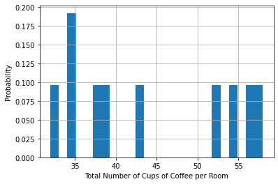

```python
plt.hist(many_rooms, bins=25, density=True)
plt.xlabel("Total Number of Cups of Coffee per Room")
plt.ylabel("Probability")
plt.grid()
plt.show()
```